# Package Test

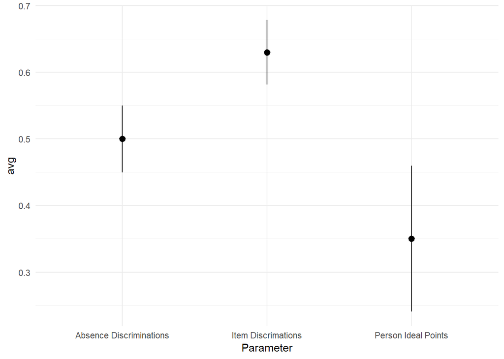

```r
id_sim_coverage(ord_irt_grm_abs_est) %>%
  bind_rows(.id='Parameter') %>%
  ggplot(aes(y=avg,x=Parameter)) +
  stat_summary(fun.args=list(mult=1.96)) +
  theme_minimal()
```

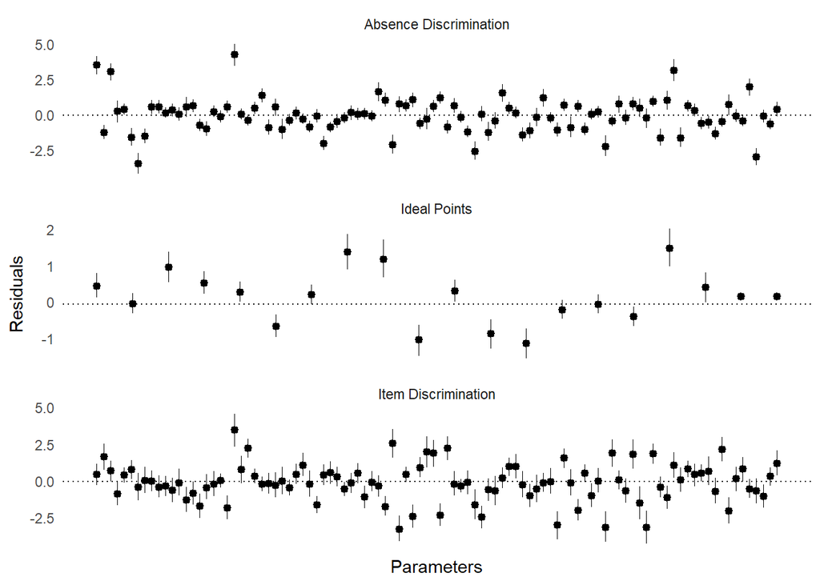

```r
id_plot_sims(ord_irt_grm_abs_est,type='Residuals')
```

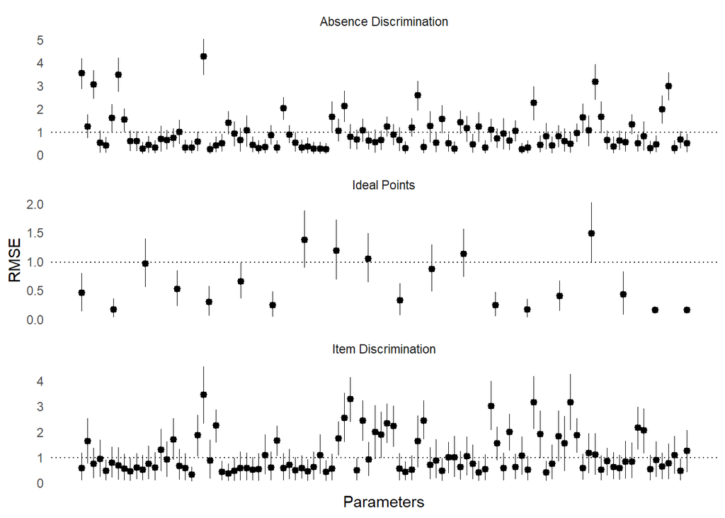

```r
id_plot_sims(ord_irt_grm_abs_est)
```

```
## [1] "Processing posterior replications for 2000 scores using 100 posterior samples out of a total of 4000 samples."
```

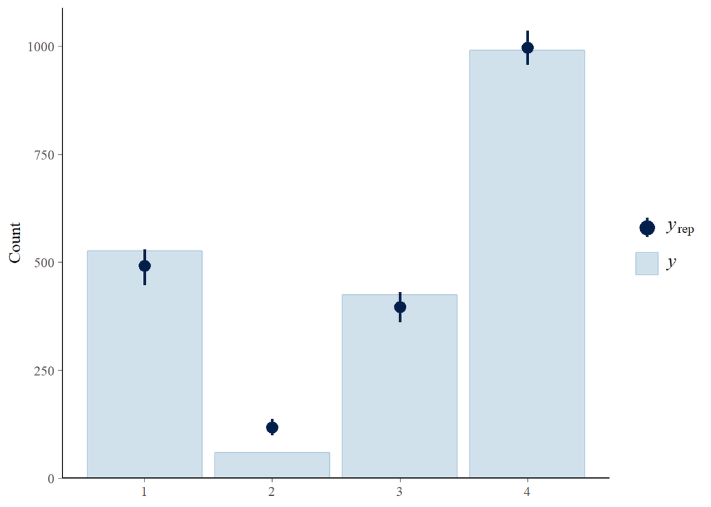

```r
ord_irt_grm_abs_est %>%
  id_post_pred %>%
  id_plot_ppc(ord_irt_grm_abs_est,ppc_pred=.)
```

# Additional Models V0.3

Models I am adding to this release include the Poisson model:

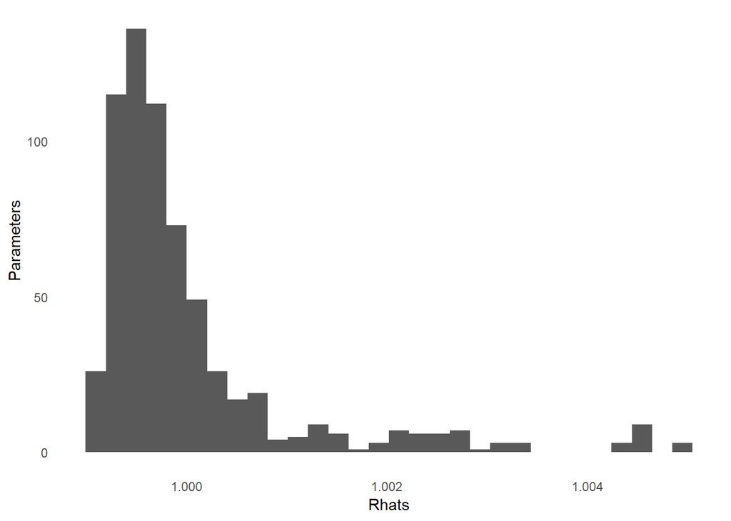

```r
ord_irt_poisson_sim <- id_sim_gen(num_person=20,num_bills=100,inflate=F,
                               absence_diff_mean=0,model_type='poisson')
ord_irt_poisson_est <- id_estimate(idealdata=ord_irt_poisson_sim,
                               model_type=7,
                               restrict_ind_high = as.character(sort(ord_irt_poisson_sim@simul_data$true_person,
                                                                     decreasing=T,
                                                        index=T)$ix[1]),
                              restrict_ind_low = as.character(sort(ord_irt_poisson_sim@simul_data$true_person,
                                                                   decreasing=F,
                                                        index=T)$ix[1]),
                               fixtype='constrained',id_diff =sort(ord_irt_poisson_sim@simul_data$true_person,
                                                                   decreasing=T)[1] -
                                sort(ord_irt_poisson_sim@simul_data$true_person,
                                  decreasing=F)[1])
id_plot_rhats(ord_irt_poisson_est)
```

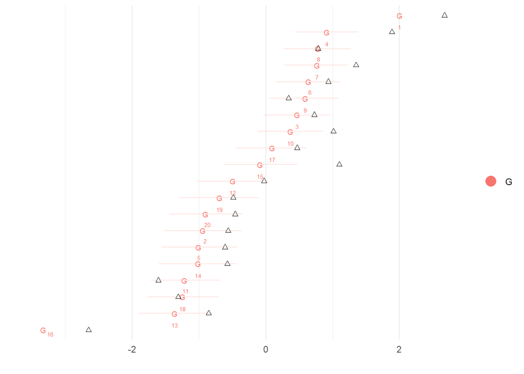

```r
id_plot_legis(ord_irt_poisson_est,show_true = T)
```

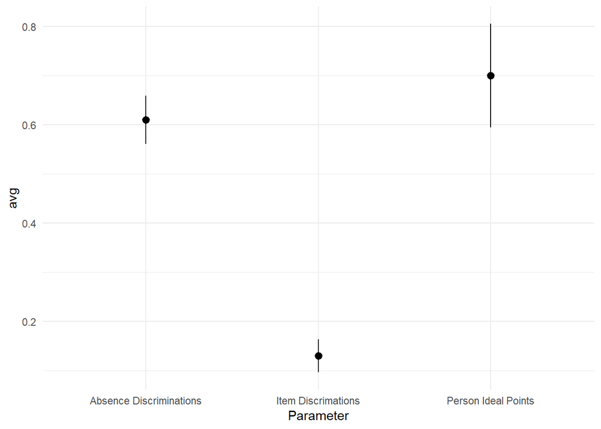

```r
id_sim_coverage(ord_irt_poisson_est) %>%
  bind_rows(.id='Parameter') %>%
  ggplot(aes(y=avg,x=Parameter)) +
  stat_summary(fun.args=list(mult=1.96)) +
  theme_minimal()
```

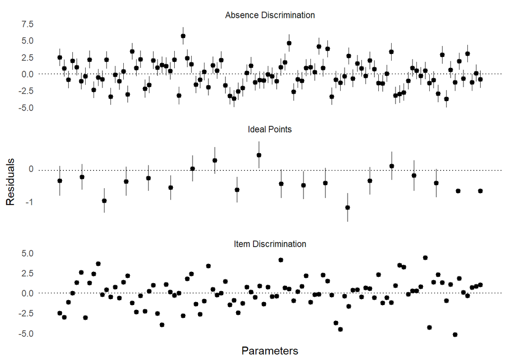

```r
id_plot_sims(ord_irt_poisson_est,type='Residuals')
```

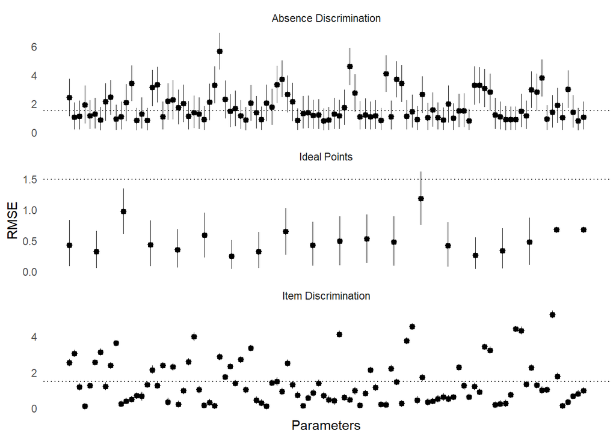

```r
id_plot_sims(ord_irt_poisson_est)
```

```
## [1] "Processing posterior replications for 2000 scores using 100 posterior samples out of a total of 4000 samples."
```

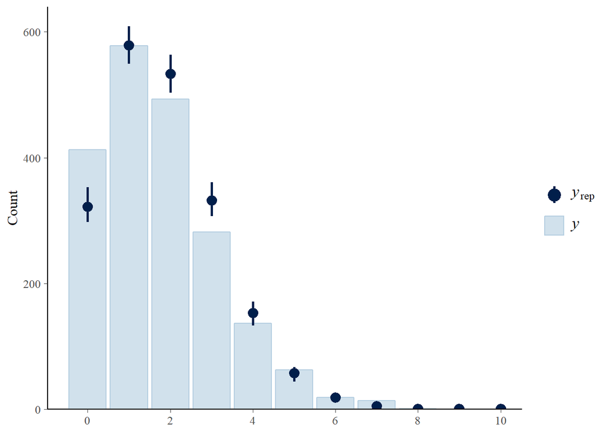

```r
ord_irt_poisson_est %>%
  id_post_pred %>%
  id_plot_ppc(ord_irt_poisson_est,ppc_pred=.)
```

Now Poisson-inflated:

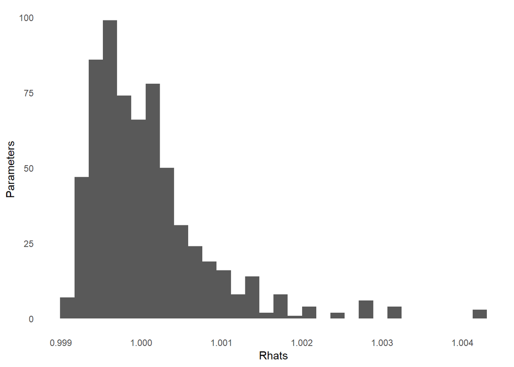

```r
ord_irt_poisson_abs_sim <- id_sim_gen(num_person=20,num_bills=100,inflate=T,
                               absence_diff_mean=0,model_type='poisson')
ord_irt_poisson_abs_est <- id_estimate(idealdata=ord_irt_poisson_abs_sim,
                               model_type=8,
                               restrict_ind_high = as.character(sort(ord_irt_poisson_abs_sim@simul_data$true_person,
                                                                     decreasing=T,
                                                        index=T)$ix[1]),
                              restrict_ind_low = as.character(sort(ord_irt_poisson_abs_sim@simul_data$true_person,
                                                                   decreasing=F,
                                                        index=T)$ix[1]),
                               fixtype='constrained',id_diff =sort(ord_irt_poisson_abs_sim@simul_data$true_person,
                                                                   decreasing=T)[1] -
                                sort(ord_irt_poisson_abs_sim@simul_data$true_person,
                                  decreasing=F)[1])
id_plot_rhats(ord_irt_poisson_abs_est)
```

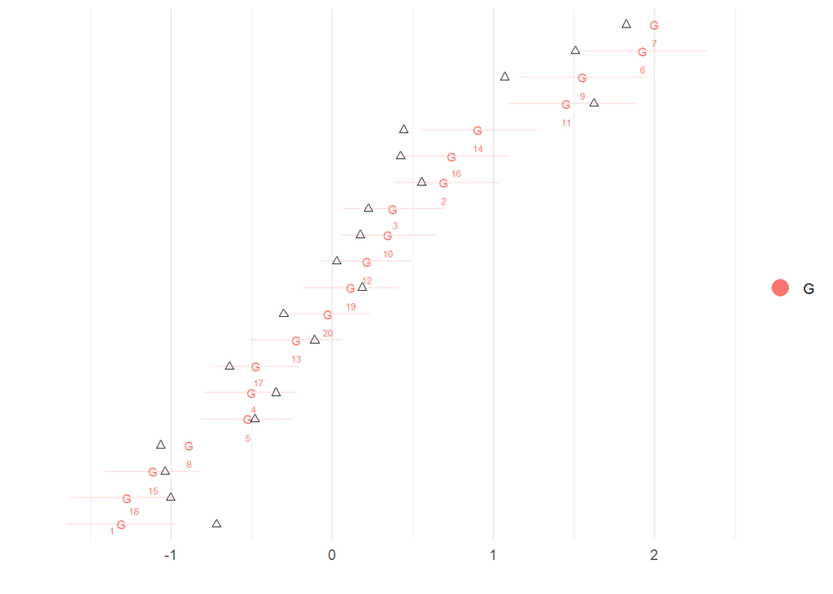

```r
id_plot_legis(ord_irt_poisson_abs_est,show_true = T)
```

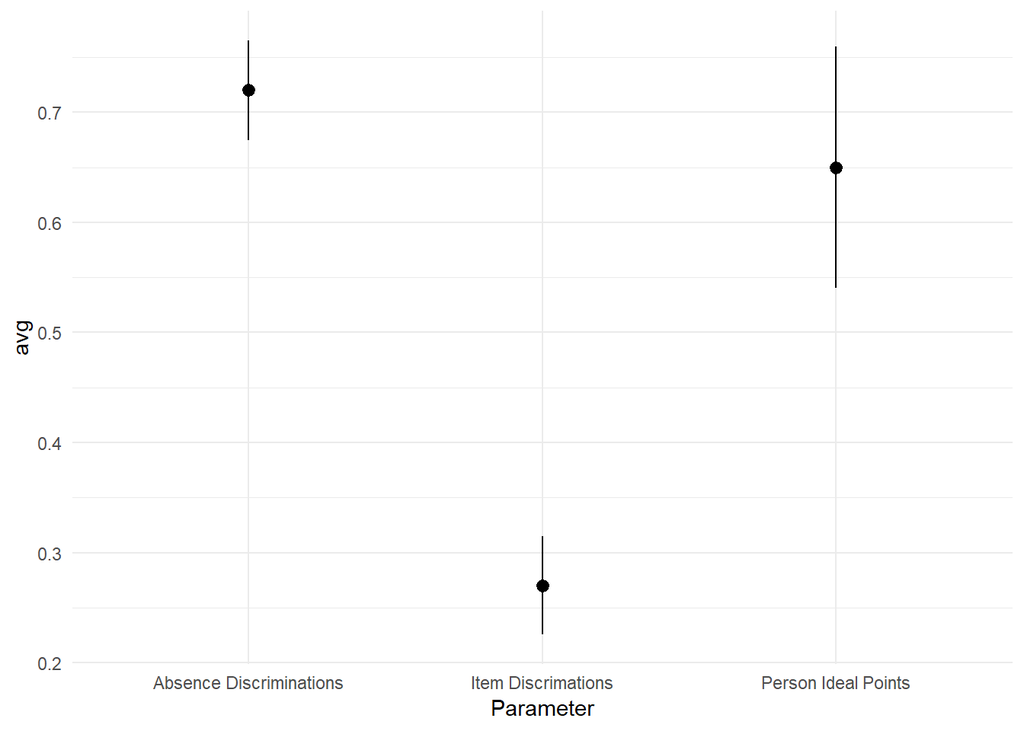

```r
id_sim_coverage(ord_irt_poisson_abs_est) %>%
  bind_rows(.id='Parameter') %>%
  ggplot(aes(y=avg,x=Parameter)) +
  stat_summary(fun.args=list(mult=1.96)) +
  theme_minimal()
```

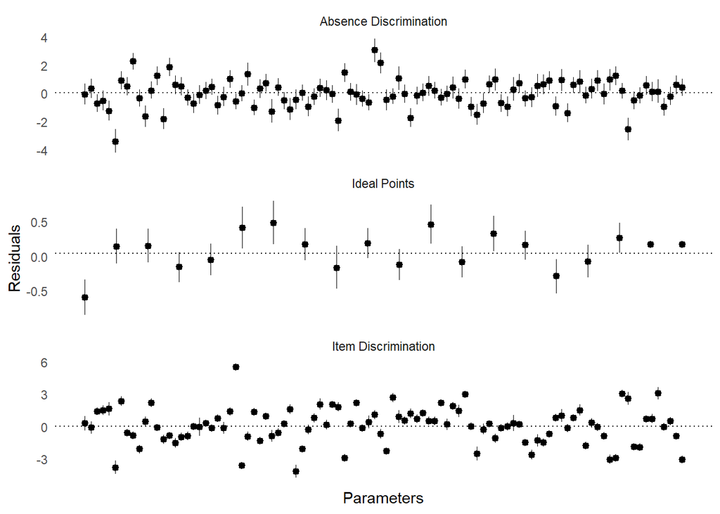

```r
id_plot_sims(ord_irt_poisson_abs_est,type='Residuals')
```

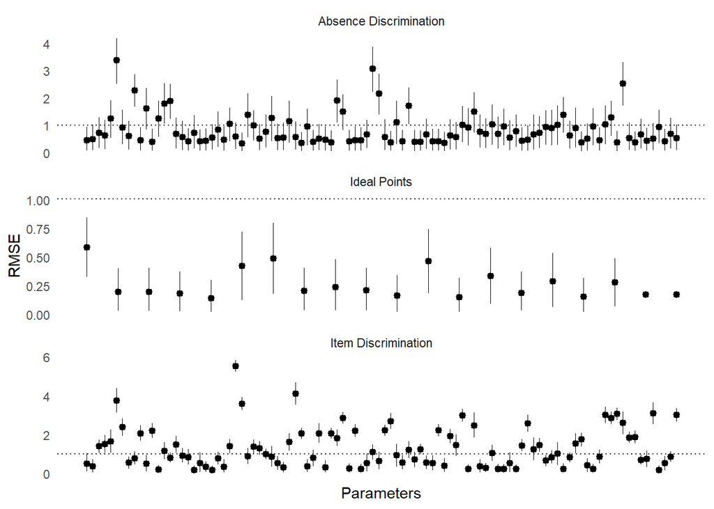

```r
id_plot_sims(ord_irt_poisson_abs_est)
```

```
## [1] "Processing posterior replications for 2000 scores using 100 posterior samples out of a total of 4000 samples."
```

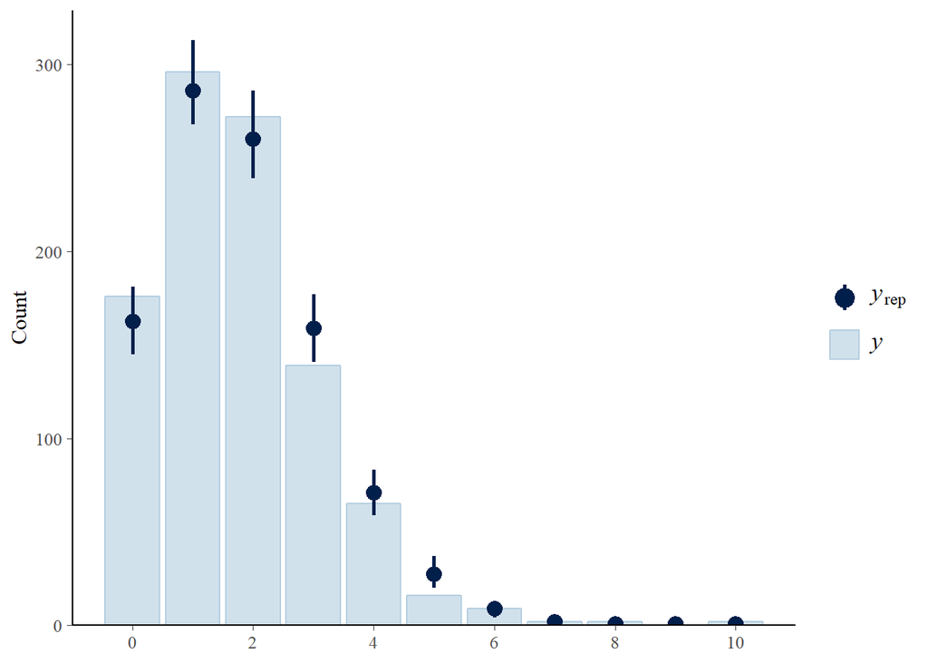

```r
ord_irt_poisson_abs_est %>%
  id_post_pred %>%
  id_plot_ppc(ord_irt_poisson_abs_est,ppc_pred=.)
```

```
## [1] "Processing posterior replications for 2000 scores using 100 posterior samples out of a total of 4000 samples."
```

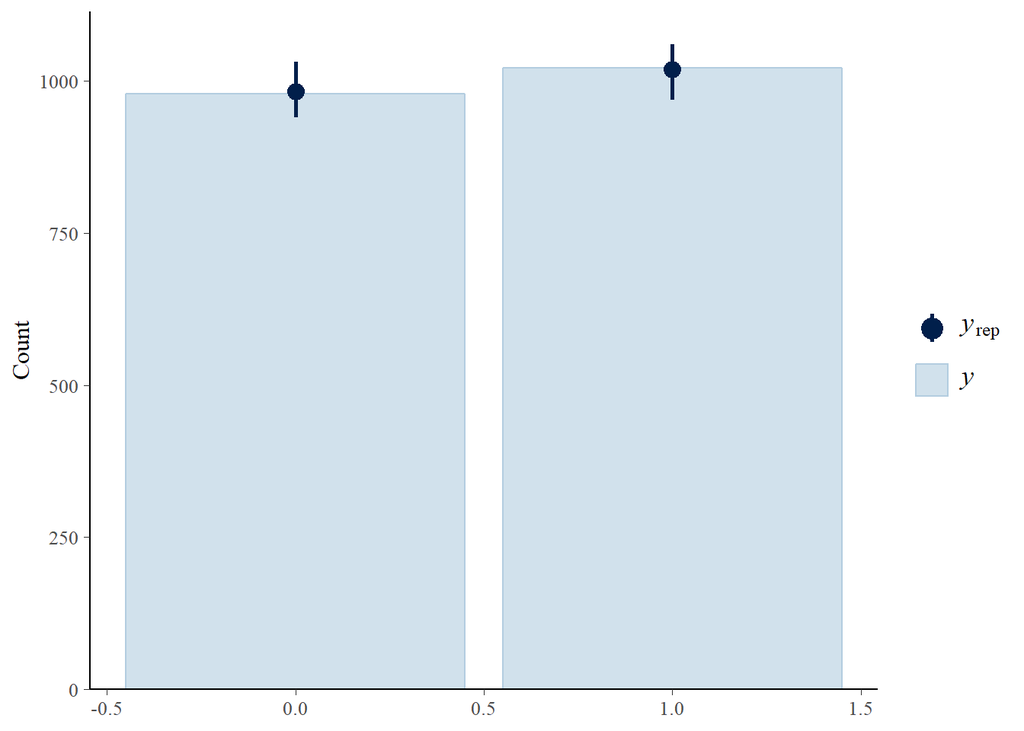

```r
ord_irt_poisson_abs_est %>%
  id_post_pred(output='missing') %>%
  id_plot_ppc(ord_irt_poisson_abs_est,ppc_pred=.)
```

A Normally-distributed outcome with no inflation:

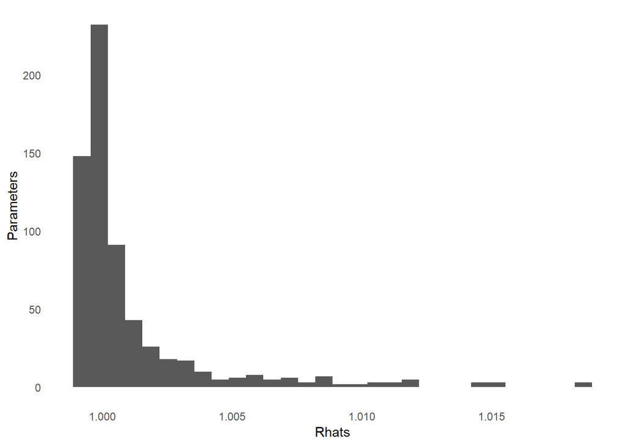

```r
ord_irt_normal_sim <- id_sim_gen(num_person=20,num_bills=100,ordinal=F,inflate=F,
                               absence_diff_mean=0,model_type='normal')
ord_irt_normal_est <- id_estimate(idealdata=ord_irt_normal_sim,
                               model_type=9,
                               restrict_ind_high = as.character(sort(ord_irt_normal_sim@simul_data$true_person,
                                                                     decreasing=T,
                                                        index=T)$ix[1]),
                              restrict_ind_low = as.character(sort(ord_irt_normal_sim@simul_data$true_person,
                                                                   decreasing=F,
                                                        index=T)$ix[1]),
                               fixtype='constrained',id_diff =sort(ord_irt_normal_sim@simul_data$true_person,
                                                                   decreasing=T)[1] -
                                sort(ord_irt_normal_sim@simul_data$true_person,
                                  decreasing=F)[1])
id_plot_rhats(ord_irt_normal_est)
```

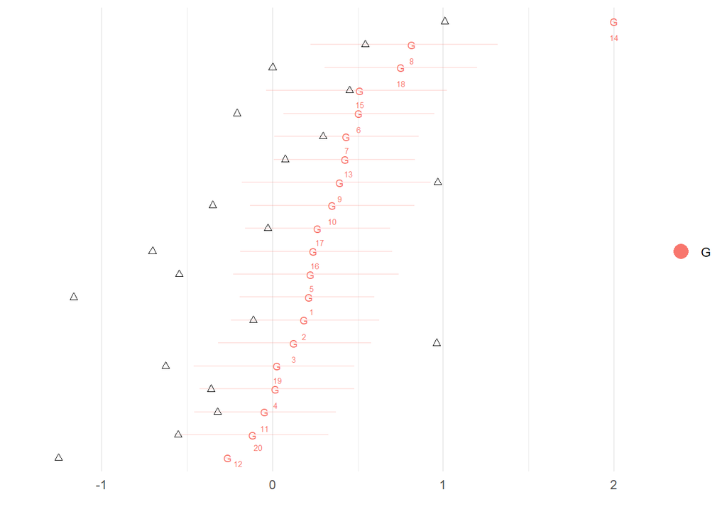

```r
id_plot_legis(ord_irt_normal_est,show_true = T)
```

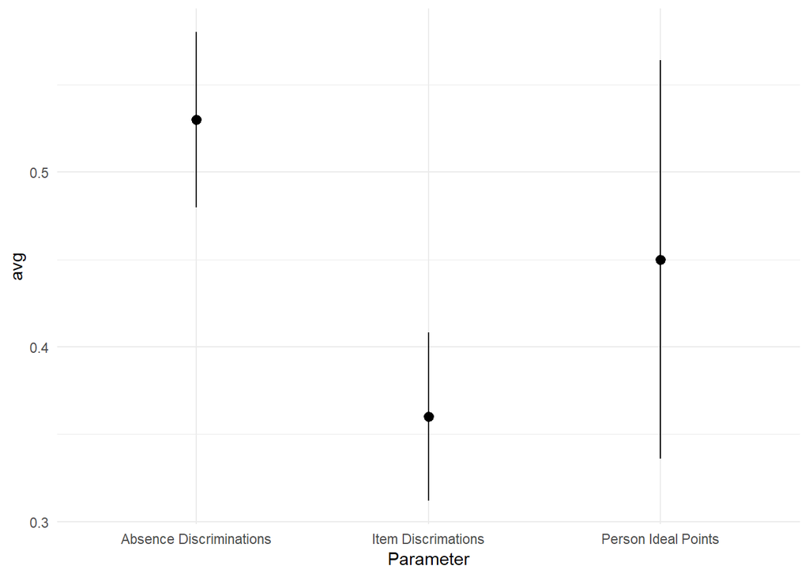

```r
id_sim_coverage(ord_irt_normal_est) %>%
  bind_rows(.id='Parameter') %>%
  ggplot(aes(y=avg,x=Parameter)) +
  stat_summary(fun.args=list(mult=1.96)) +
  theme_minimal()
```

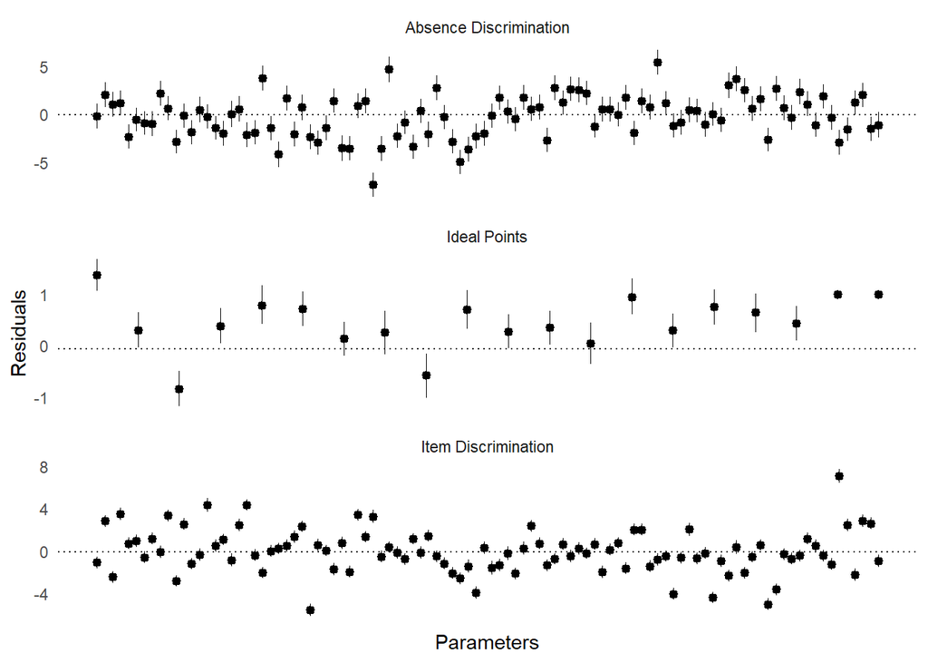

```r
id_plot_sims(ord_irt_normal_est,type='Residuals')
```

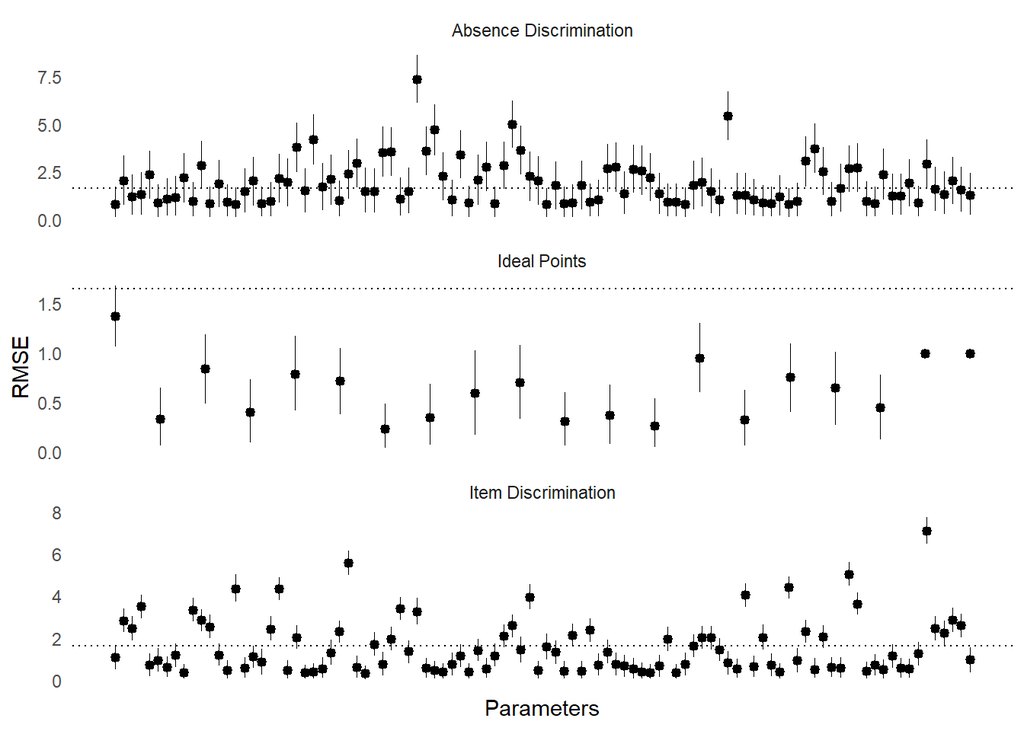

```r
id_plot_sims(ord_irt_normal_est)
```

```
## [1] "Processing posterior replications for 2000 scores using 100 posterior samples out of a total of 4000 samples."
```

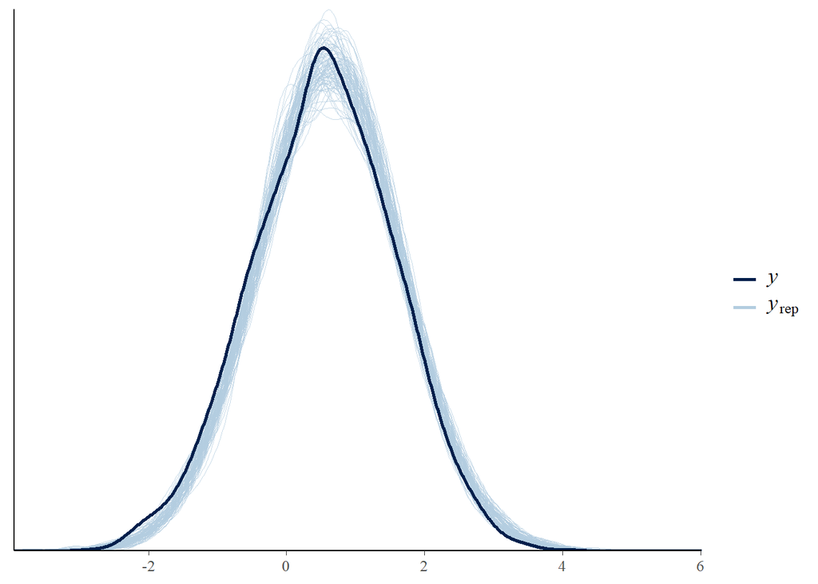

```r
ord_irt_normal_est %>%
  id_post_pred %>%
  id_plot_ppc(ord_irt_normal_est,ppc_pred=.)
```

A Normally-distributed outcome with inflation:

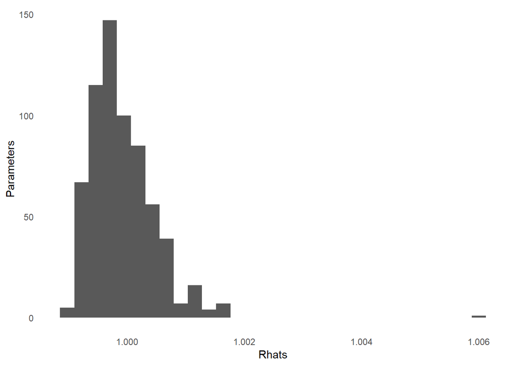

```r
ord_irt_normal_abs_sim <- id_sim_gen(num_person=20,num_bills=100,inflate=T,
                               absence_diff_mean=0,model_type='normal')
ord_irt_normal_abs_est <- id_estimate(idealdata=ord_irt_normal_abs_sim,
                               model_type=10,
                               restrict_ind_high = as.character(sort(ord_irt_normal_abs_sim@simul_data$true_person,
                                                                     decreasing=T,
                                                        index=T)$ix[1]),
                              restrict_ind_low = as.character(sort(ord_irt_normal_abs_sim@simul_data$true_person,
                                                                   decreasing=F,
                                                        index=T)$ix[1]),
                               fixtype='constrained',id_diff =sort(ord_irt_normal_abs_sim@simul_data$true_person,
                                                                   decreasing=T)[1] -
                                sort(ord_irt_normal_abs_sim@simul_data$true_person,
                                  decreasing=F)[1])
id_plot_rhats(ord_irt_normal_abs_est)
```

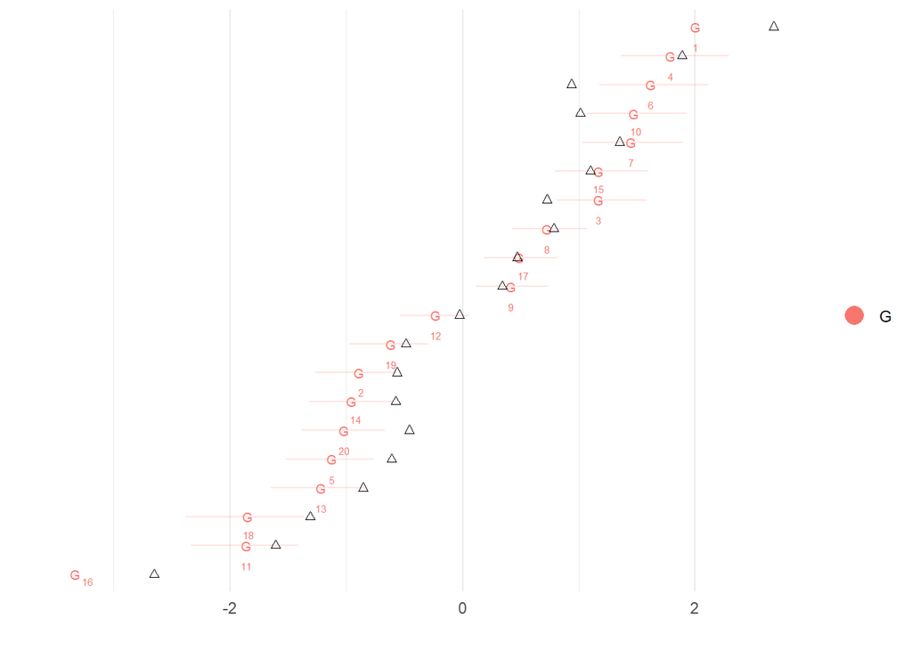

```r
id_plot_legis(ord_irt_normal_abs_est,show_true = T)
```

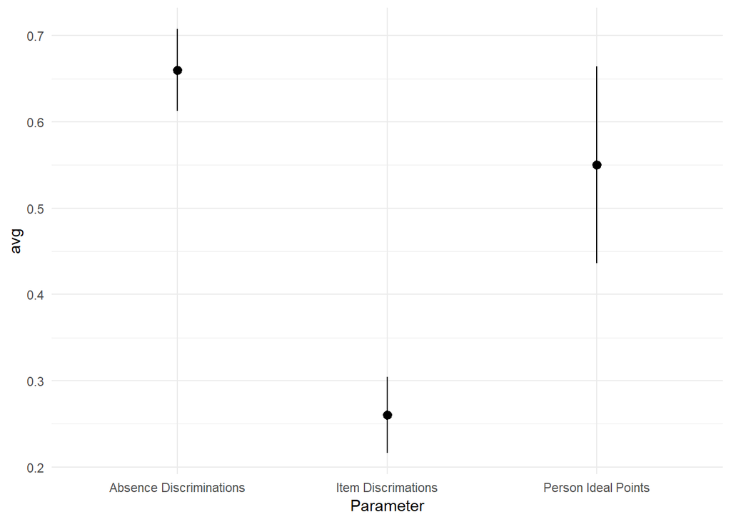

```r
id_sim_coverage(ord_irt_normal_abs_est) %>%
  bind_rows(.id='Parameter') %>%
  ggplot(aes(y=avg,x=Parameter)) +
  stat_summary(fun.args=list(mult=1.96)) +
  theme_minimal()
```

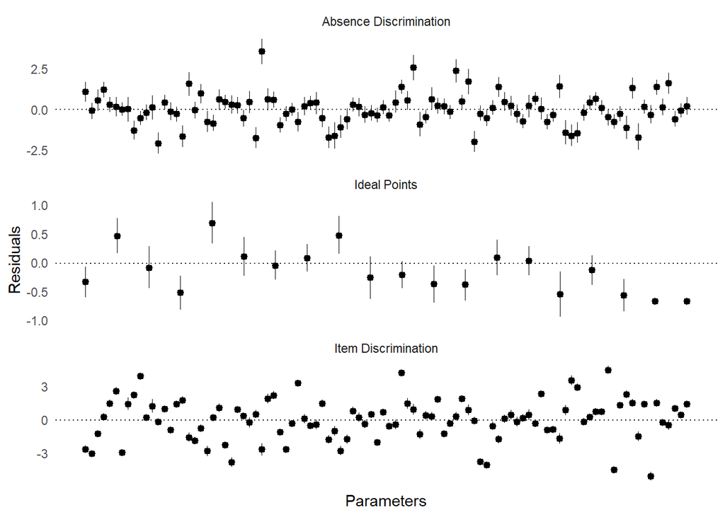

```r
id_plot_sims(ord_irt_normal_abs_est,type='Residuals')
```

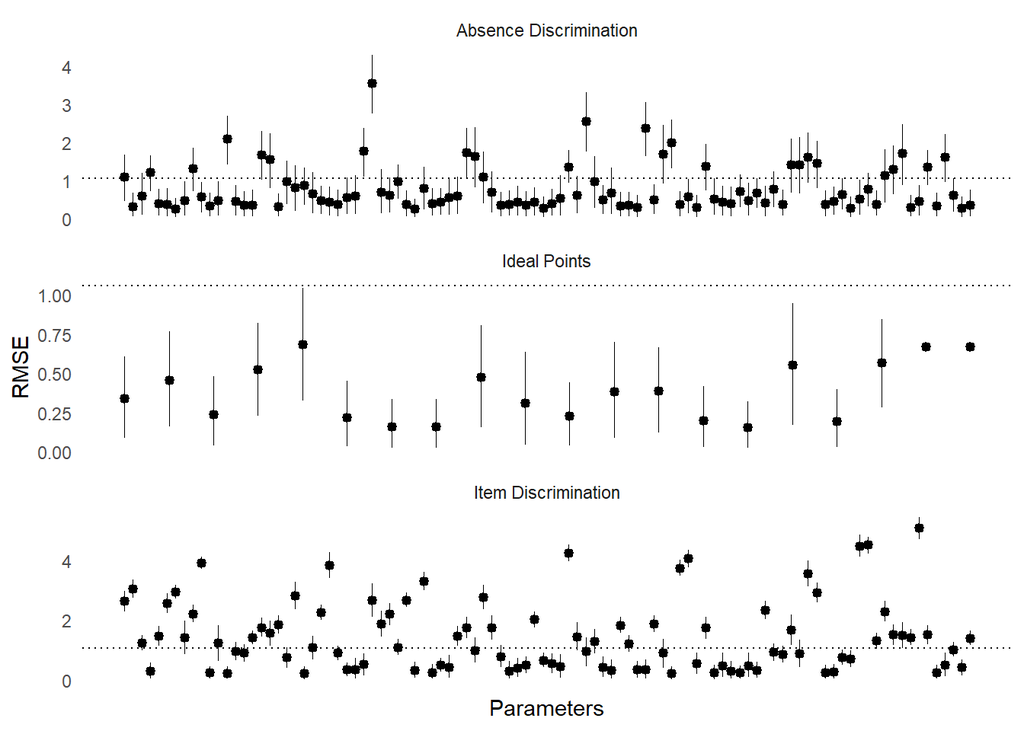

```r
id_plot_sims(ord_irt_normal_abs_est)
```

```
## [1] "Processing posterior replications for 2000 scores using 100 posterior samples out of a total of 4000 samples."
```

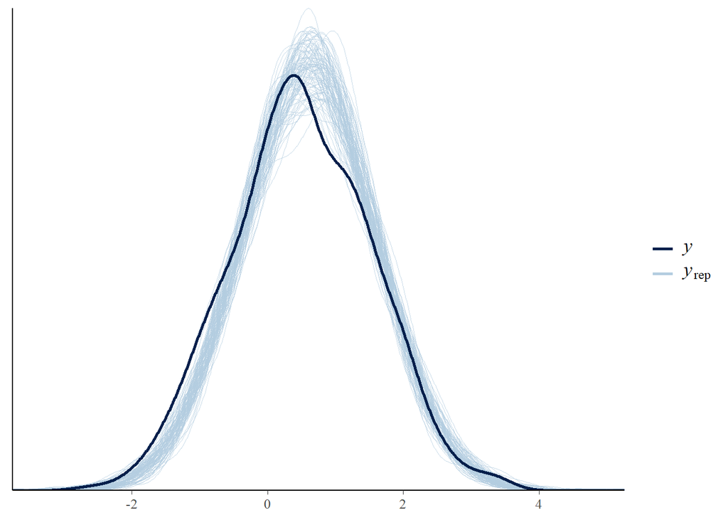

```r
ord_irt_normal_abs_est %>%
  id_post_pred %>%
  id_plot_ppc(ord_irt_normal_abs_est,ppc_pred=.)
```

```
## [1] "Processing posterior replications for 2000 scores using 100 posterior samples out of a total of 4000 samples."
```

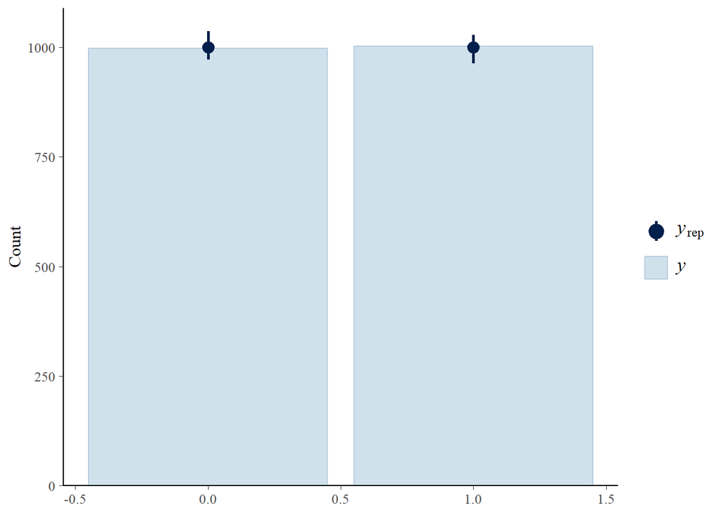

```r
ord_irt_normal_abs_est %>%
  id_post_pred(output='missing') %>%
  id_plot_ppc(ord_irt_normal_abs_est,ppc_pred=.)
```

A Lognormal model with no inflation:

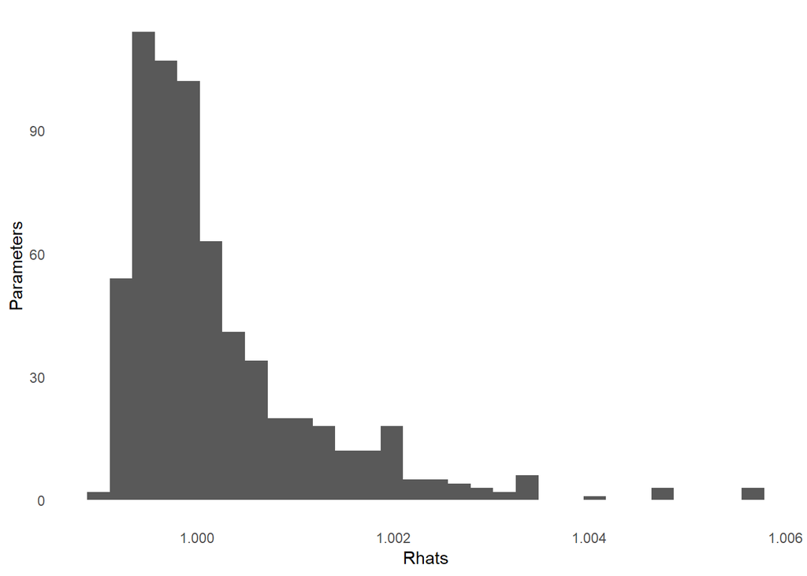

```r
ord_irt_lognormal_sim <- id_sim_gen(num_person=20,num_bills=100,ordinal=F,inflate=F,
                               absence_diff_mean=0,model_type='lognormal')
ord_irt_lognormal_est <- id_estimate(idealdata=ord_irt_lognormal_sim,
                               model_type=11,
                               restrict_ind_high = as.character(sort(ord_irt_lognormal_sim@simul_data$true_person,
                                                                     decreasing=T,
                                                        index=T)$ix[1]),
                              restrict_ind_low = as.character(sort(ord_irt_lognormal_sim@simul_data$true_person,
                                                                   decreasing=F,
                                                        index=T)$ix[1]),
                               fixtype='constrained',id_diff =sort(ord_irt_lognormal_sim@simul_data$true_person,
                                                                   decreasing=T)[1] -
                                sort(ord_irt_lognormal_sim@simul_data$true_person,
                                  decreasing=F)[1])
id_plot_rhats(ord_irt_lognormal_est)
```

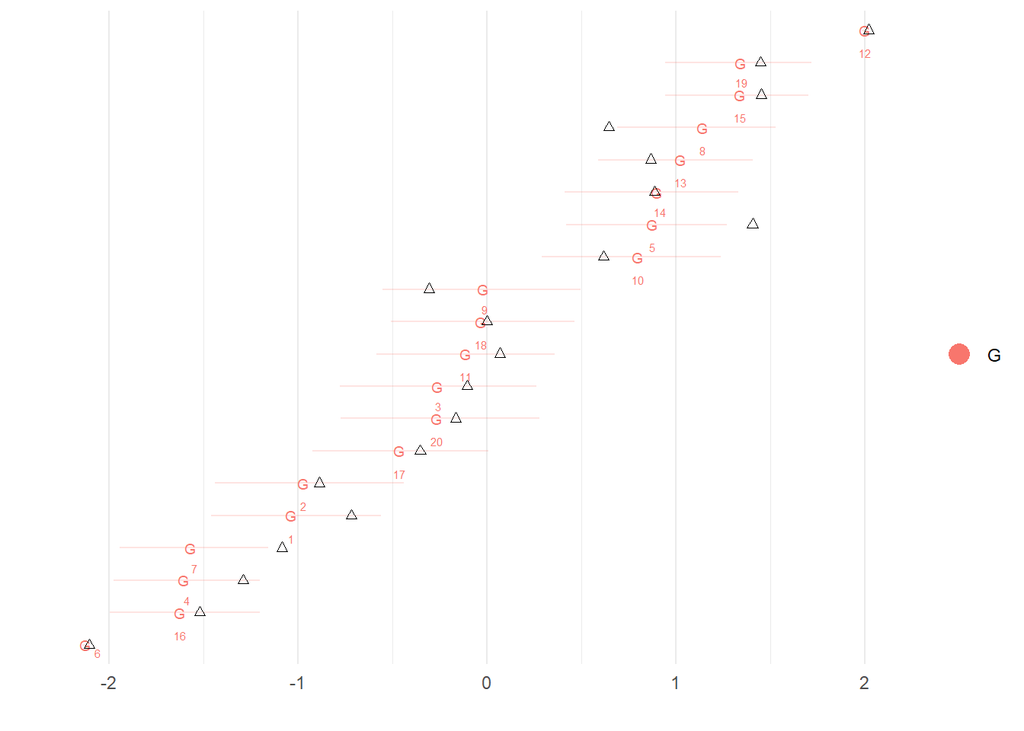

```r
id_plot_legis(ord_irt_lognormal_est,show_true = T)
```

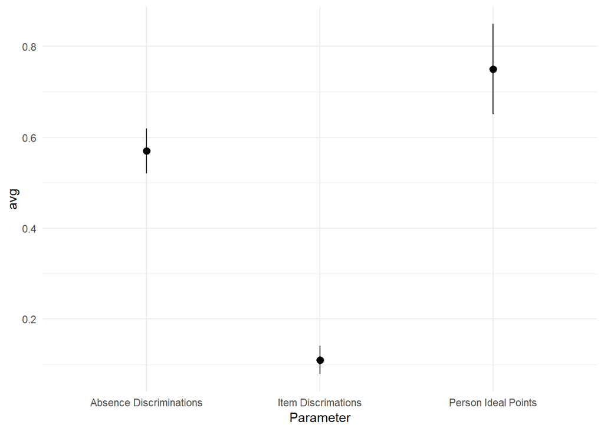

```r
id_sim_coverage(ord_irt_lognormal_est) %>%
  bind_rows(.id='Parameter') %>%
  ggplot(aes(y=avg,x=Parameter)) +
  stat_summary(fun.args=list(mult=1.96)) +
  theme_minimal()
```

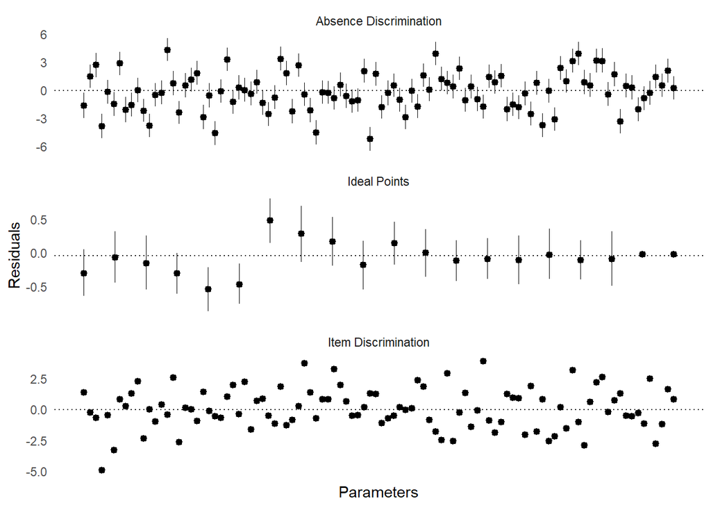

```r
id_plot_sims(ord_irt_lognormal_est,type='Residuals')
```

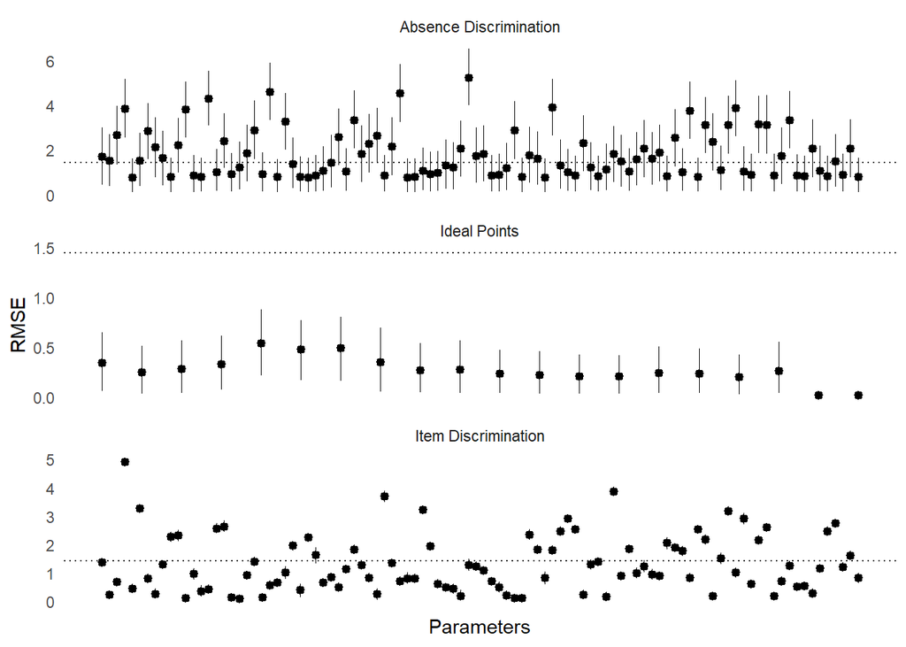

```r
id_plot_sims(ord_irt_lognormal_est)
```

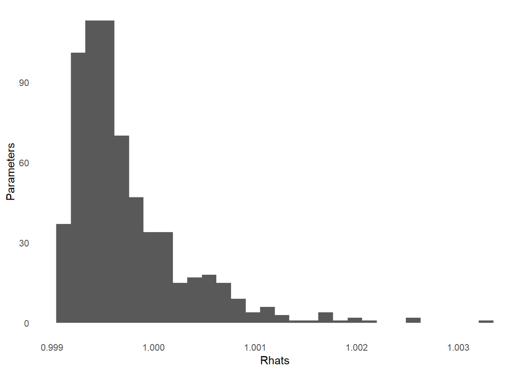

```r
ord_irt_lognormal_abs_sim <- id_sim_gen(num_person=20,num_bills=100,ordinal=F,inflate=F,
                               absence_diff_mean=0,model_type='lognormal')
ord_irt_lognormal_abs_est <- id_estimate(idealdata=ord_irt_lognormal_abs_sim,
                               model_type=12,
                               restrict_ind_high = as.character(sort(ord_irt_lognormal_abs_sim@simul_data$true_person,
                                                                     decreasing=T,
                                                        index=T)$ix[1]),
                              restrict_ind_low = as.character(sort(ord_irt_lognormal_abs_sim@simul_data$true_person,
                                                                   decreasing=F,
                                                        index=T)$ix[1]),
                               fixtype='constrained',id_diff =sort(ord_irt_lognormal_abs_sim@simul_data$true_person,
                                                                   decreasing=T)[1] -
                                sort(ord_irt_lognormal_abs_sim@simul_data$true_person,
                                  decreasing=F)[1])
id_plot_rhats(ord_irt_lognormal_abs_est)
```

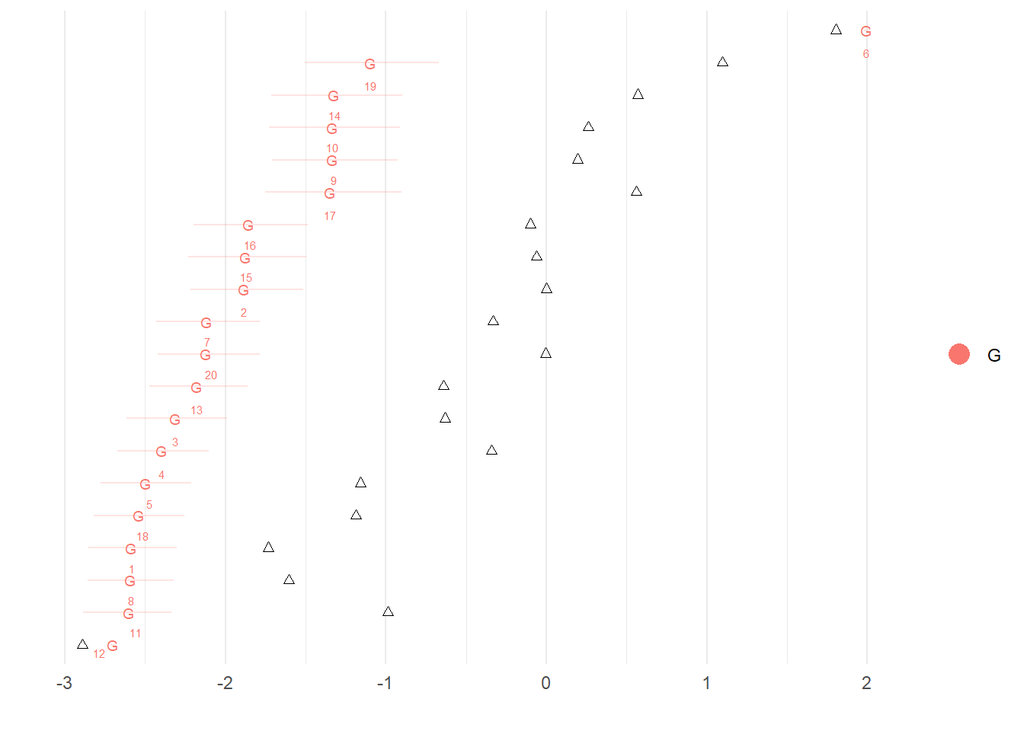

```r
id_plot_legis(ord_irt_lognormal_abs_est,show_true = T)
```

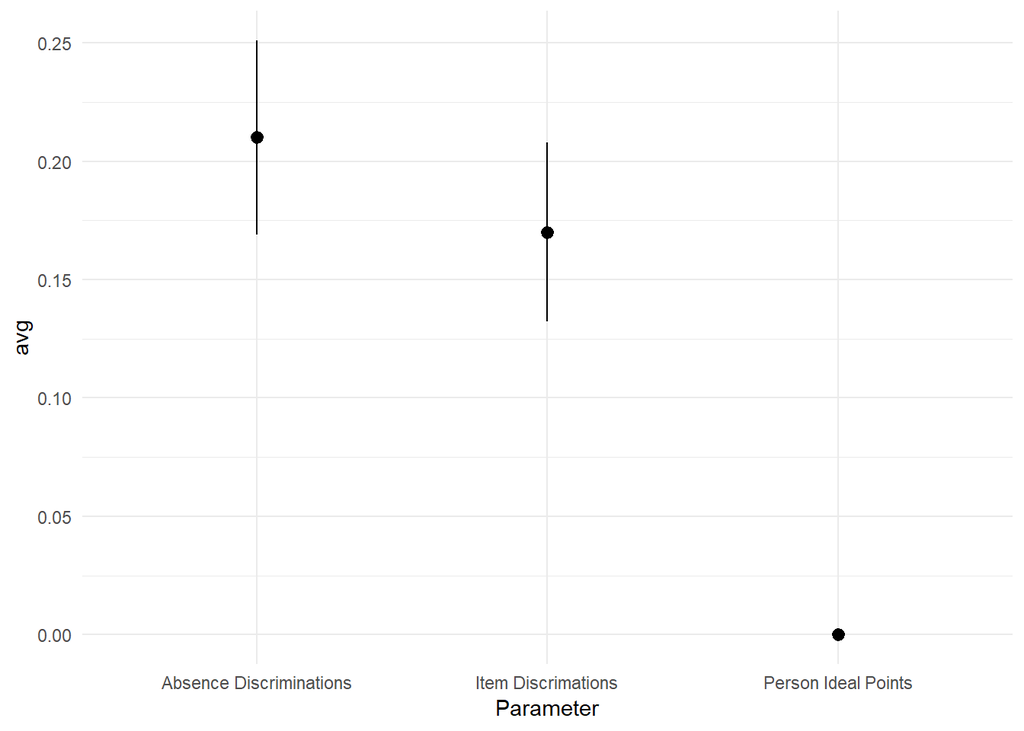

```r
id_sim_coverage(ord_irt_lognormal_abs_est) %>%
  bind_rows(.id='Parameter') %>%
  ggplot(aes(y=avg,x=Parameter)) +
  stat_summary(fun.args=list(mult=1.96)) +
  theme_minimal()
```

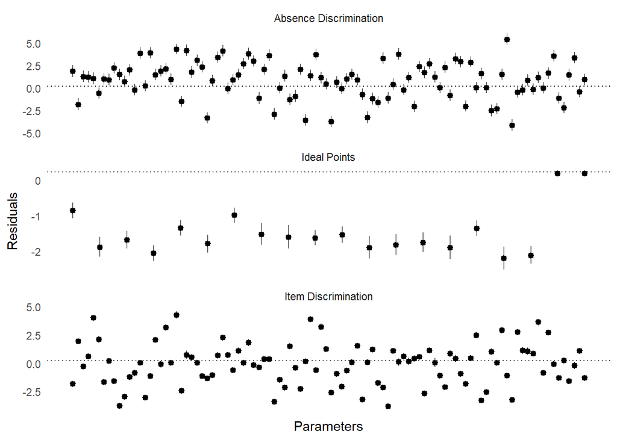

```r
id_plot_sims(ord_irt_lognormal_abs_est,type='Residuals')
```

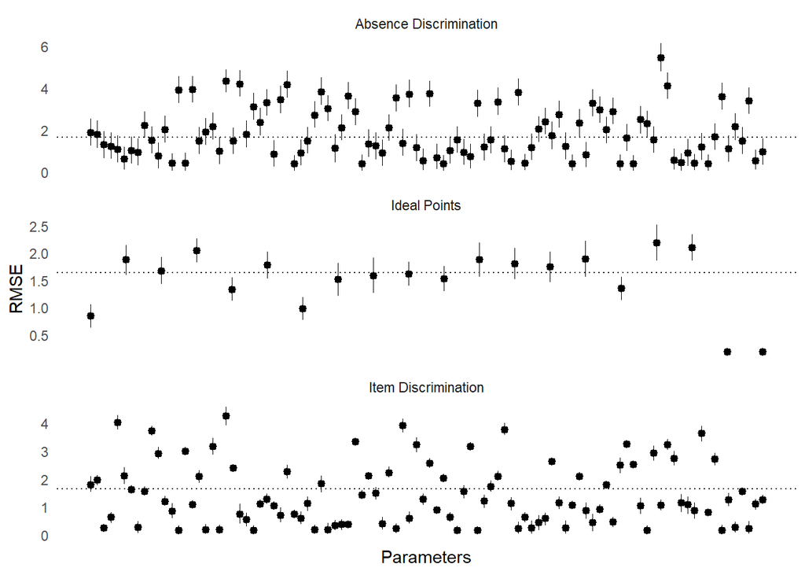

```r
id_plot_sims(ord_irt_lognormal_abs_est)
```

# Testing for Time

We won’t test all the possible time auto-correlation settings, only a subset of them. I use an inflated binary model as it is a very common one.

While these models are identified, it appears that sometimes given the amount of data, they are only weakly identified in the posterior and Rhat values higher than 1.1 are possible (but are not evidence of multi-modality).

First random walks:

```r
bin_time_irt_2pl_abs_sim <- id_sim_gen(num_person=20,num_bills=125,ordinal=F,inflate=T,
                               absence_diff_mean=0,time_process = 'random',time_points=25,ideal_pts_sd = 1,
diff_sd = 1,
                               absence_discrim_sd = 1,
                               reg_discrim_sd = 1)
bin_time_irt_2pl_abs_est <- id_estimate(idealdata=bin_time_irt_2pl_abs_sim,
                               model_type=2,
                               vary_ideal_pts = 'random_walk',
                               restrict_ind_high = as.character(sort(bin_time_irt_2pl_abs_sim@simul_data$drift,
                                                                     decreasing=TRUE,
                                                        index=T)$ix[1]),
                              restrict_ind_low = as.character(sort(bin_time_irt_2pl_abs_sim@simul_data$drift,
                                                                   decreasing=F,
                                                        index=T)$ix[1]),
                               fixtype='vb_partial',
                              id_diff = sort(bin_time_irt_2pl_abs_sim@simul_data$drift,decreasing=TRUE)[1] -
                             sort(bin_time_irt_2pl_abs_sim@simul_data$drift,decreasing=F)[1],

                             id_diff_high=sort(bin_time_irt_2pl_abs_sim@simul_data$drift,
                                                  decreasing=TRUE)[1])
```

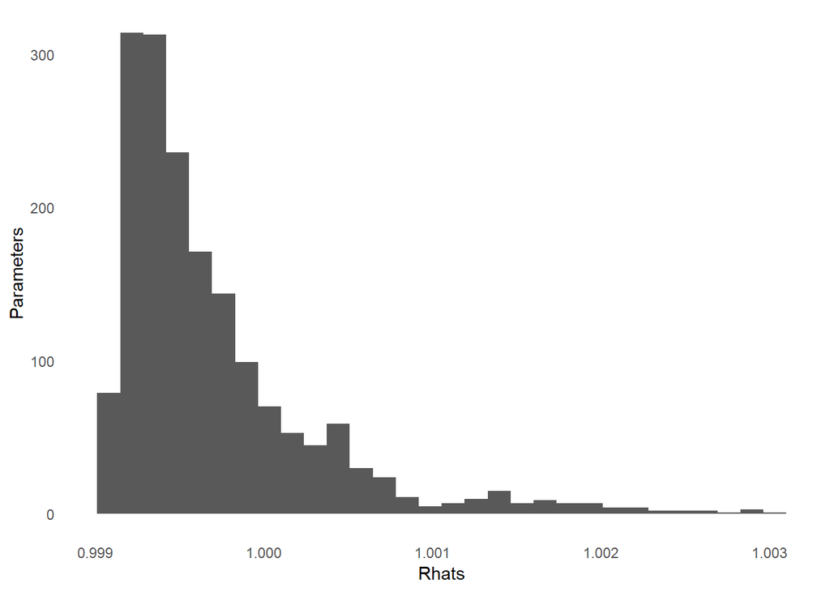

```r
id_plot_rhats(bin_time_irt_2pl_abs_est)
```

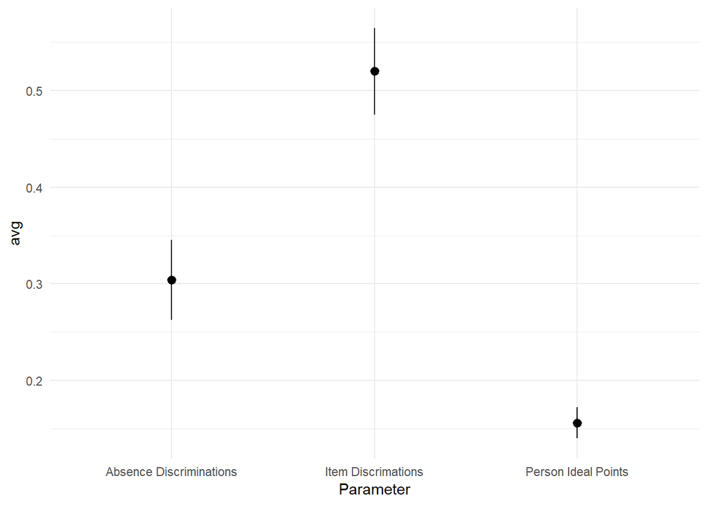

```r
id_sim_coverage(bin_time_irt_2pl_abs_est) %>%
  bind_rows(.id='Parameter') %>%
  ggplot(aes(y=avg,x=Parameter)) +
  stat_summary(fun.args=list(mult=1.96)) +
  theme_minimal()
```

Let’s do a time-varying ideal point plot with true point overlay:

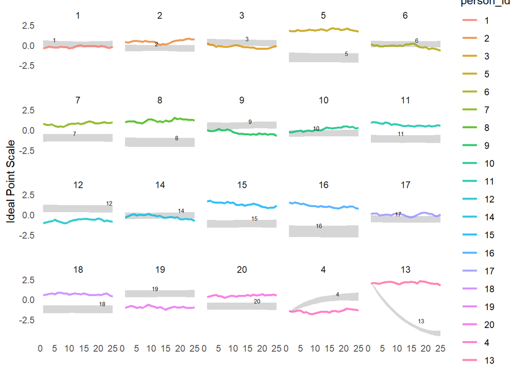

```r
id_plot_legis_dyn(bin_time_irt_2pl_abs_est,plot_sim = T) + facet_wrap(~person_id)
```

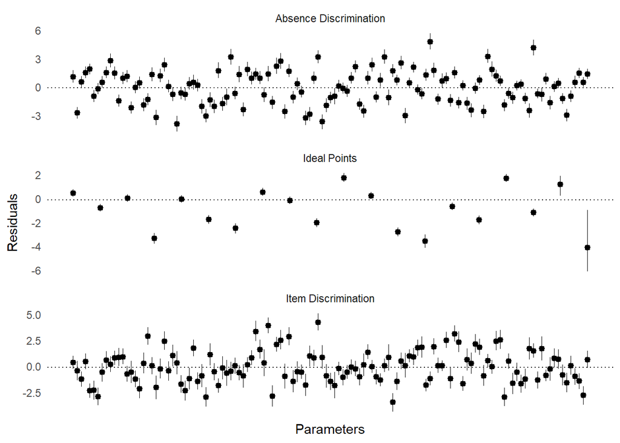

```r
id_plot_sims(bin_time_irt_2pl_abs_est,type='Residuals')
```

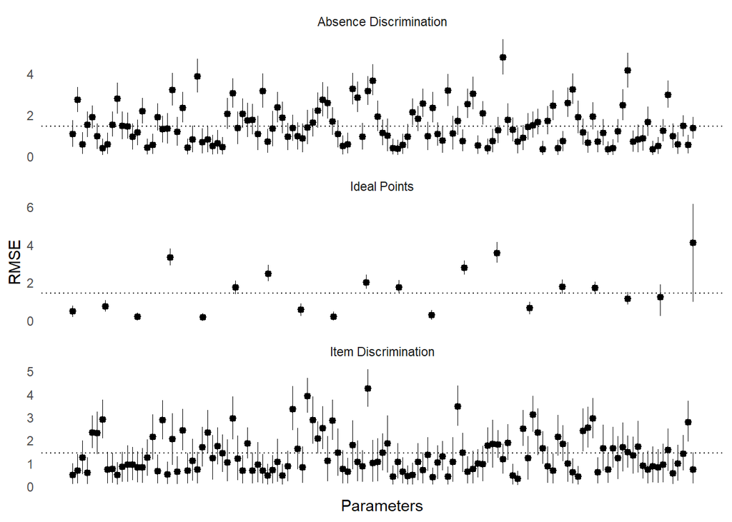

```r
id_plot_sims(bin_time_irt_2pl_abs_est)
```

And autocorrelation:

```r
bin_time_ar_irt_2pl_abs_sim <- id_sim_gen(num_person=20,num_bills=200,inflate=T,
                               absence_diff_mean=0,time_process = 'AR',time_points=50,time_sd = .2,diff_sd = 1,
                               absence_discrim_sd = 1,
                               reg_discrim_sd = 1)
bin_time_ar_irt_2pl_abs_est <- id_estimate(idealdata=bin_time_ar_irt_2pl_abs_sim,
                               model_type=2,
                               vary_ideal_pts = 'AR1',
                               restrict_ind_high = as.character(sort(bin_time_ar_irt_2pl_abs_sim@simul_data$drift,
                                                                     decreasing=TRUE,
                                                        index=TRUE)$ix[1]),
                              restrict_ind_low = as.character(sort(bin_time_ar_irt_2pl_abs_sim@simul_data$drift,
                                                                   decreasing=F,
                                                        index=T)$ix[1]),
                               fixtype='vb_partial',
                              id_diff = sort(bin_time_ar_irt_2pl_abs_sim@simul_data$drift,
                                                  decreasing=TRUE)[1] -
                                sort(bin_time_ar_irt_2pl_abs_sim@simul_data$drift,
                                               decreasing=F)[1],
                              id_diff_high=sort(bin_time_ar_irt_2pl_abs_sim@simul_data$drift,
                                                  decreasing=TRUE)[1])
```

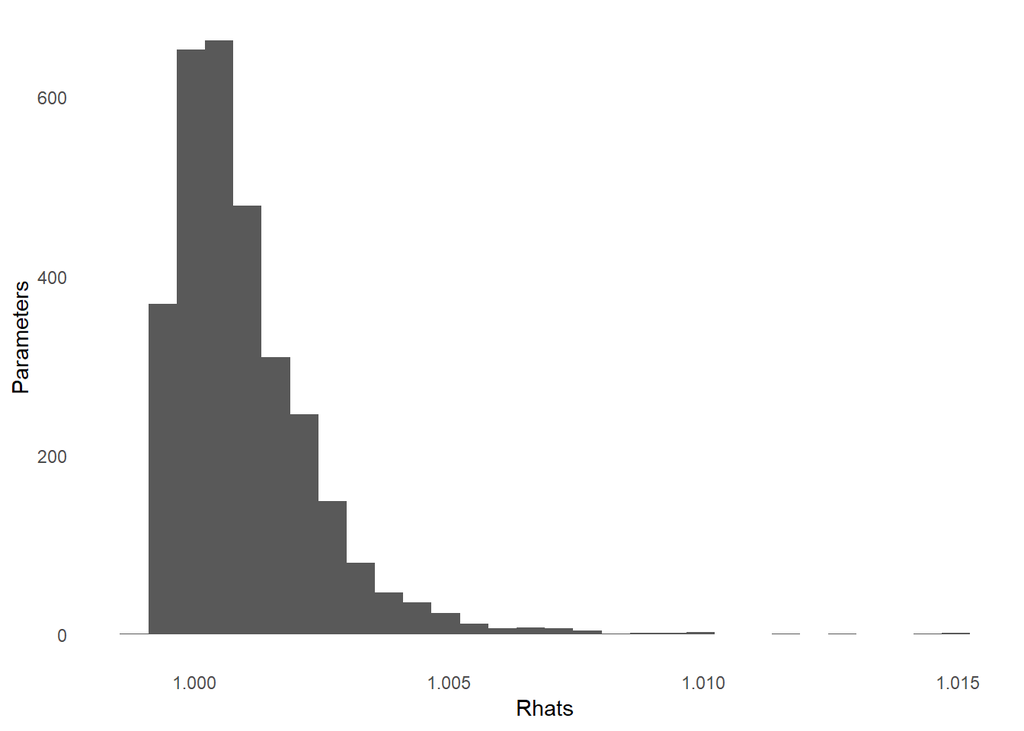

```r
id_plot_rhats(bin_time_ar_irt_2pl_abs_est)
```

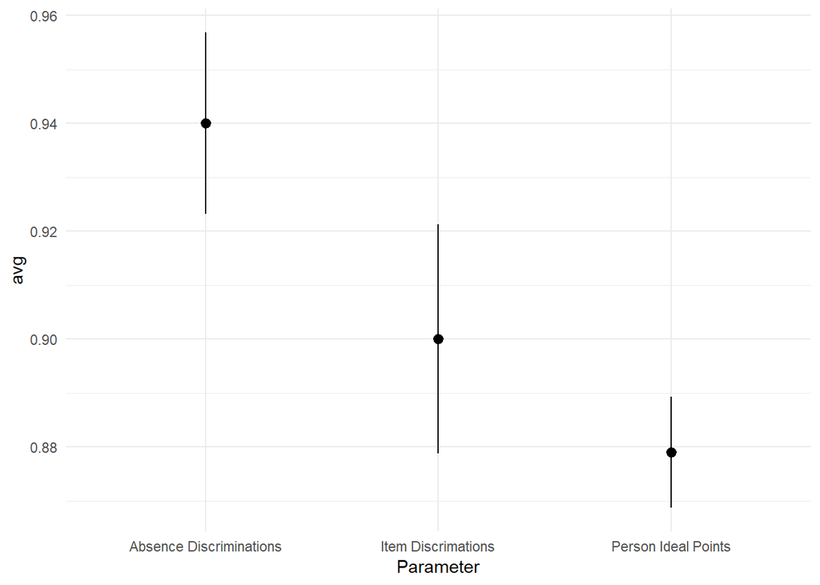

```r
id_sim_coverage(bin_time_ar_irt_2pl_abs_est) %>%
  bind_rows(.id='Parameter') %>%
  ggplot(aes(y=avg,x=Parameter)) +
  stat_summary(fun.args=list(mult=1.96)) +
  theme_minimal()
```

Let’s do a time-varying ideal point plot with true point overlay:

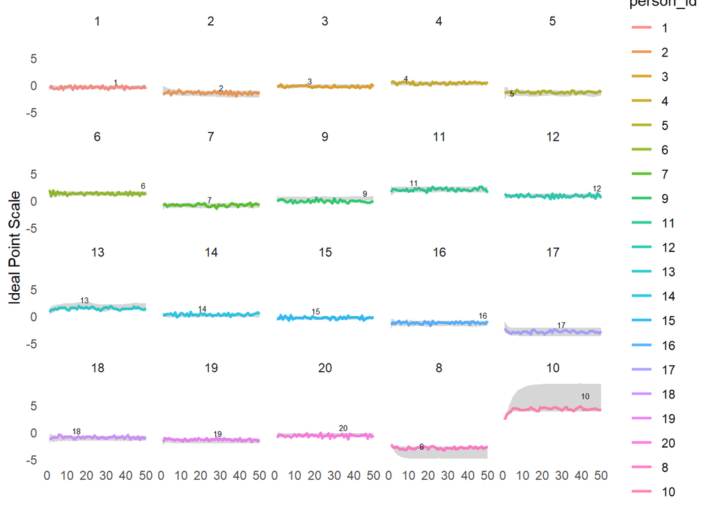

```r
id_plot_legis_dyn(bin_time_ar_irt_2pl_abs_est,plot_sim = T) +facet_wrap(~person_id)
```

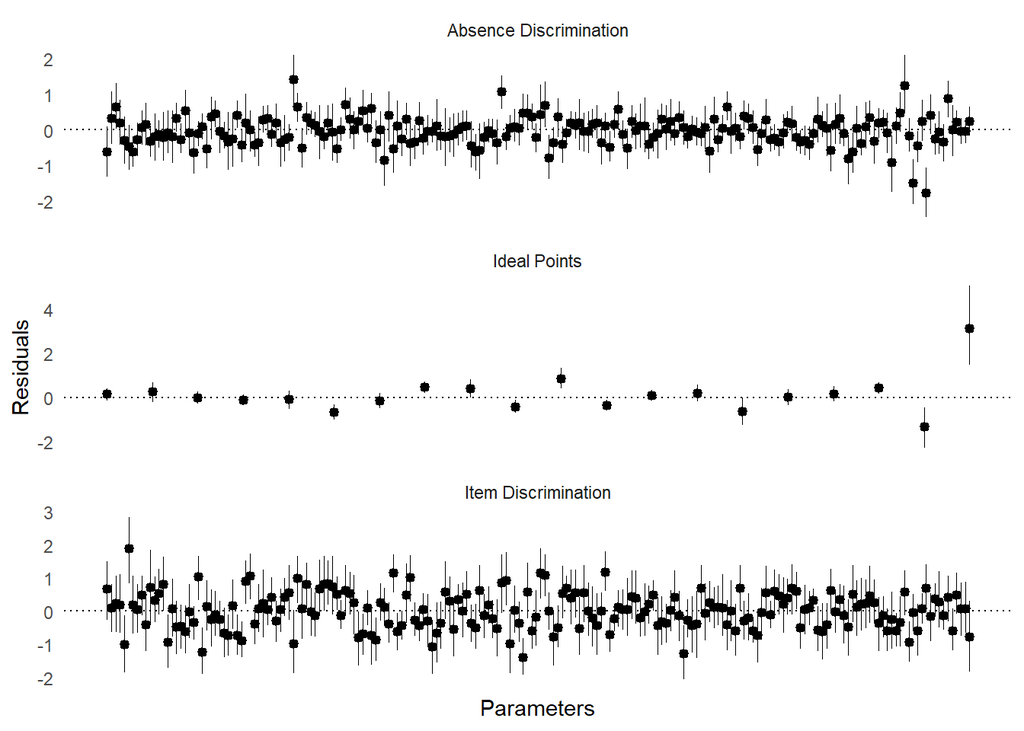

```r
id_plot_sims(bin_time_ar_irt_2pl_abs_est,type='Residuals')
```

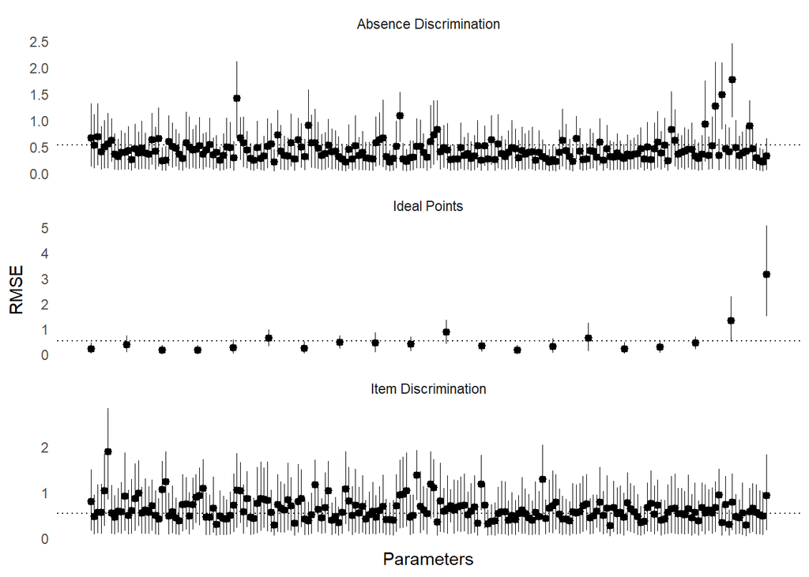

```r
id_plot_sims(bin_time_ar_irt_2pl_abs_est)
```

## Latent Space Model

Another new addition is the latent space model, which is only a slight modification on the IRT model.

Non-inflated:

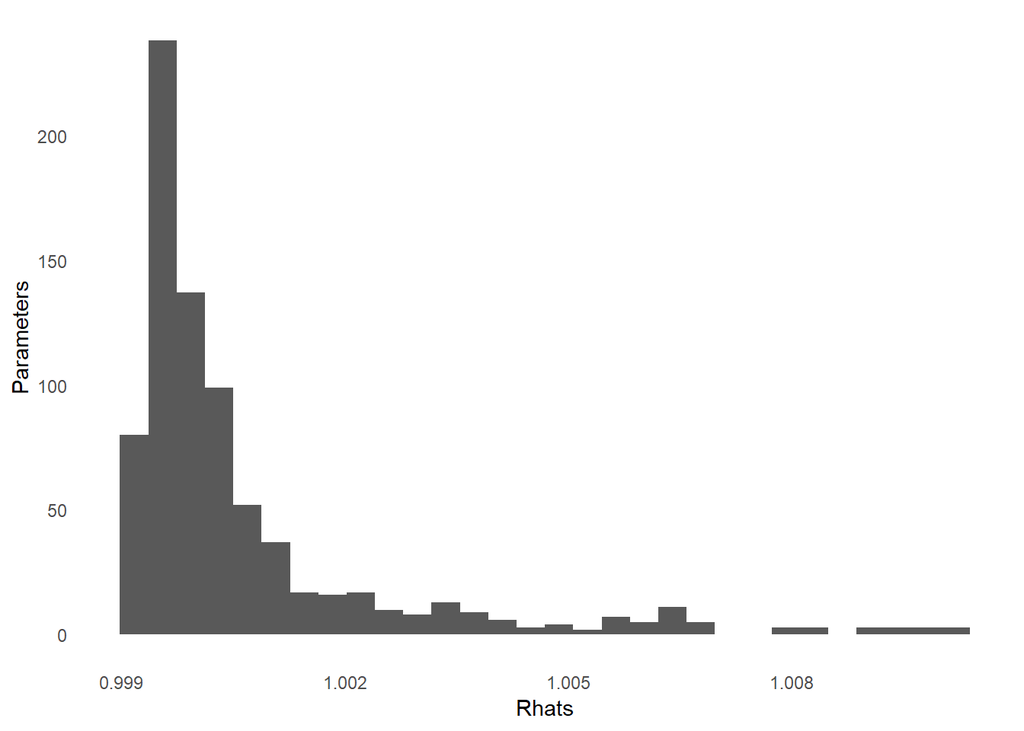

```r
latent_noninfl_sim <- id_sim_gen(num_person=20,num_bills=125,ordinal=F,
                                       inflate=F,
                                       model_type='binary',
                                       latent_space=T,
                               absence_diff_mean=0,
                               ideal_pts_sd = 1,
                               diff_sd = 1,
                               absence_discrim_sd = 1,
                               reg_discrim_sd = 1)
latent_noninfl_est <- id_estimate(idealdata=latent_noninfl_sim,
                               model_type=13,
                               restrict_ind_high = as.character(sort(latent_noninfl_sim@simul_data$true_person,
                                                                     decreasing=TRUE,
                                                        index=T)$ix[1]),
                              restrict_ind_low = as.character(sort(latent_noninfl_sim@simul_data$true_person,
                                                                   decreasing=F,
                                                        index=T)$ix[1]),
                               fixtype='constrained',
                              id_diff = sort(latent_noninfl_sim@simul_data$true_person,decreasing=TRUE)[1] -
                             sort(latent_noninfl_sim@simul_data$true_person,decreasing=F)[1],

                             id_diff_high=sort(latent_noninfl_sim@simul_data$true_person,
                                                  decreasing=TRUE)[1])
id_plot_rhats(latent_noninfl_est)
```

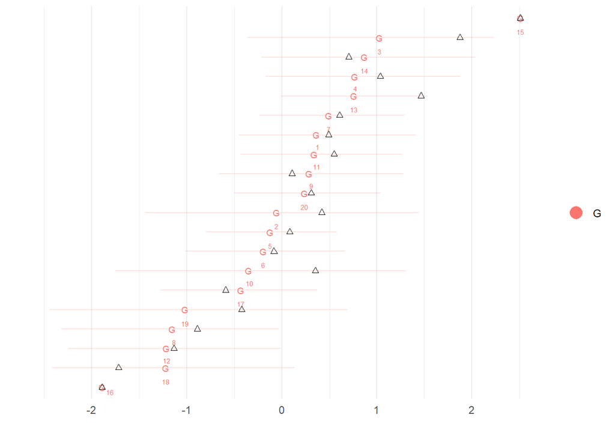

```r
id_plot_legis(latent_noninfl_est,show_true = T)
```

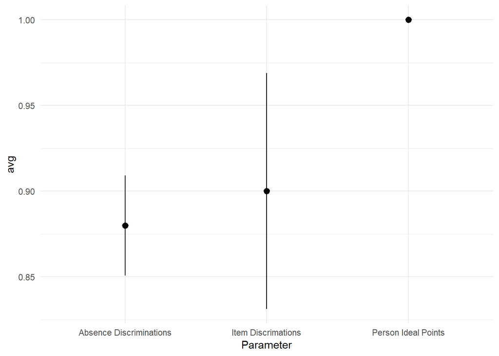

```r
id_sim_coverage(latent_noninfl_est) %>%
  bind_rows(.id='Parameter') %>%
  ggplot(aes(y=avg,x=Parameter)) +
  stat_summary(fun.args=list(mult=1.96)) +
  theme_minimal()
```

Inflated:

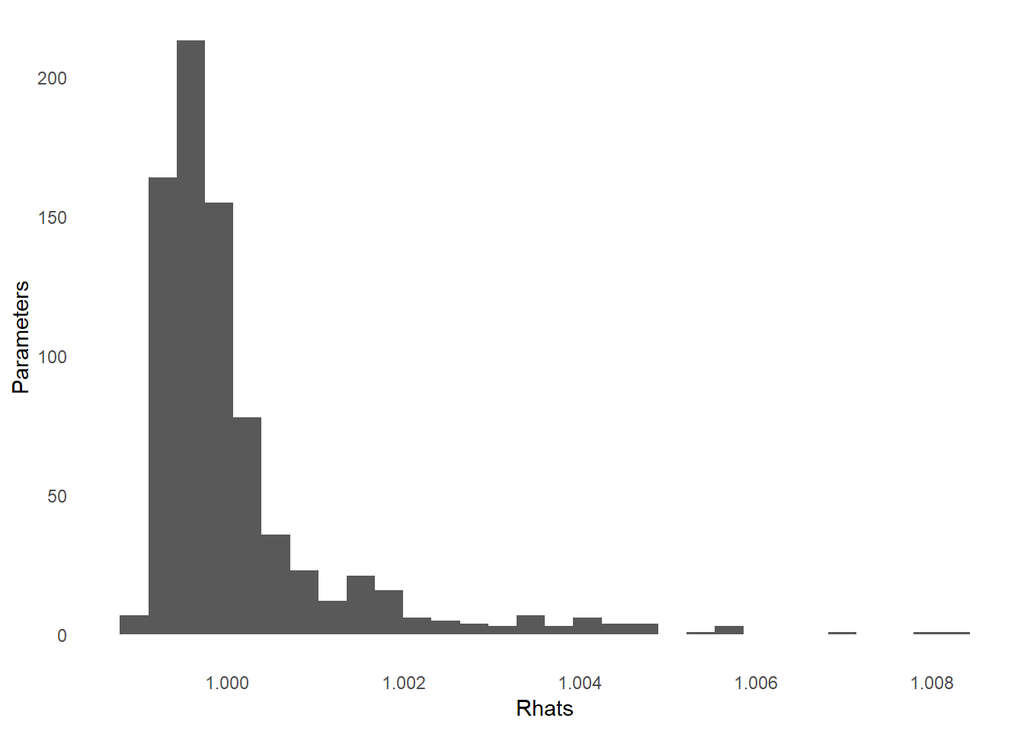

```r
# you can't have too few people relative to bills
latent_infl_sim <- id_sim_gen(num_person=20,num_bills=125,ordinal=F,
                                       inflate=T,
                                       model_type='binary',
                                       latent_space=T,
                               absence_diff_mean=0,
                               ideal_pts_sd = 1,
                               diff_sd = 1,
                               absence_discrim_sd = 1,
                               reg_discrim_sd = 1)
latent_infl_est <- id_estimate(idealdata=latent_infl_sim,
                               model_type=14,
                               restrict_ind_high = as.character(sort(latent_infl_sim@simul_data$true_person,
                                                                     decreasing=TRUE,
                                                        index=T)$ix[1]),
                              restrict_ind_low = as.character(sort(latent_infl_sim@simul_data$true_person,
                                                                   decreasing=F,
                                                        index=T)$ix[1]),
                               fixtype='constrained',
                              id_diff = sort(latent_infl_sim@simul_data$true_person,decreasing=TRUE)[1] -
                             sort(latent_infl_sim@simul_data$true_person,decreasing=F)[1],

                             id_diff_high=sort(latent_infl_sim@simul_data$true_person,
                                                  decreasing=TRUE)[1],
                              diff_reg_sd = 2,
                             diff_miss_sd=2)
id_plot_rhats(latent_infl_est)
```

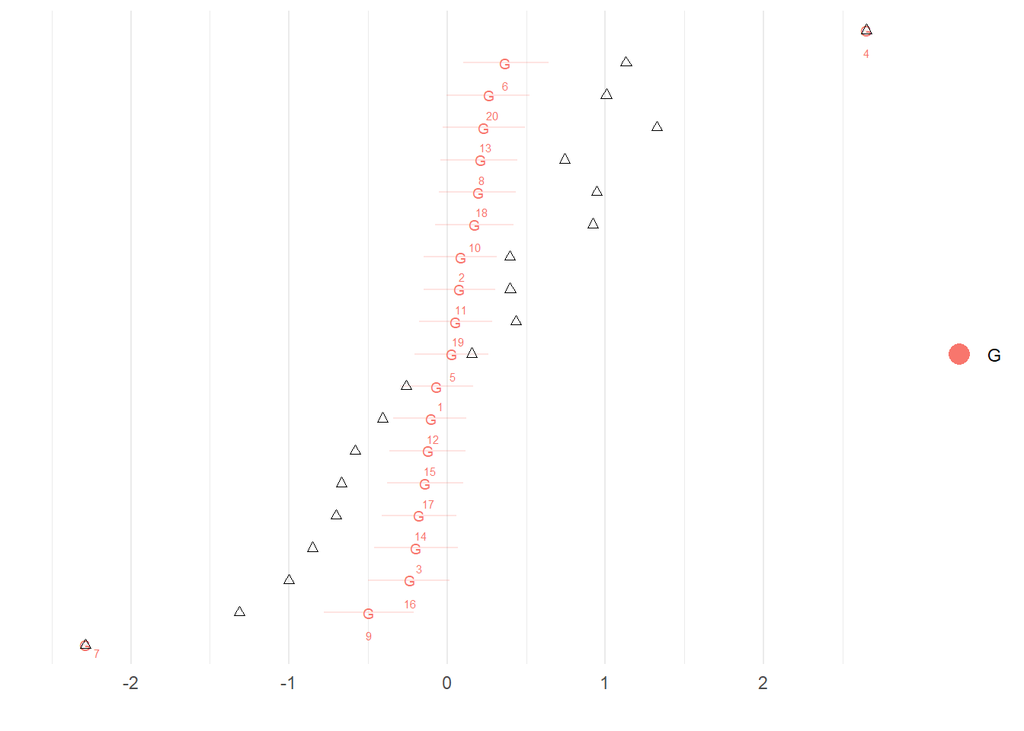

```r
id_plot_legis(latent_infl_est,show_true = T)
```

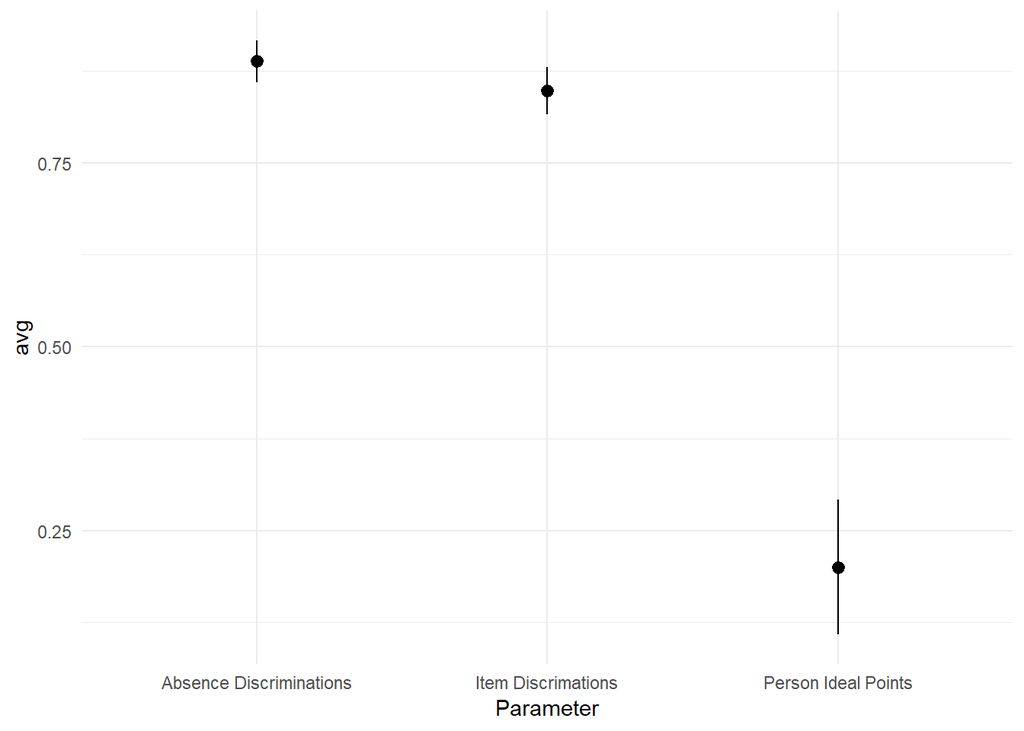

```r
id_sim_coverage(latent_infl_est) %>%
  bind_rows(.id='Parameter') %>%
  ggplot(aes(y=avg,x=Parameter)) +
  stat_summary(fun.args=list(mult=1.96)) +
  theme_minimal()
```